# EDA of Red Wine Quality Dataset by Iwan Thomas

Let’s now look at a few other relationships.

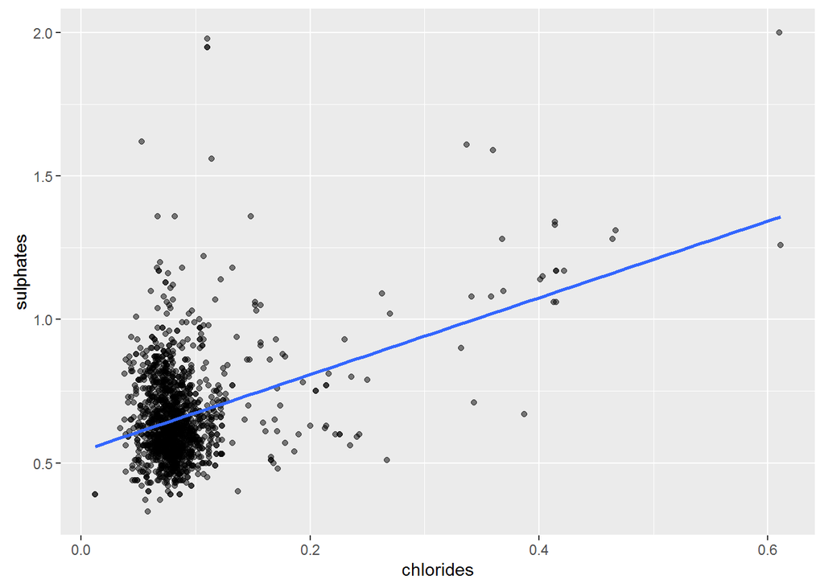

```
## [1] 0.3712605
```

The correlation matrix makes us think that chlorides and sulphates are strongly correlated. In fact, the scatterplot suggests that most wines have low sulphates and chlorides content. It is possible that a few outliers are creating a false correlation.

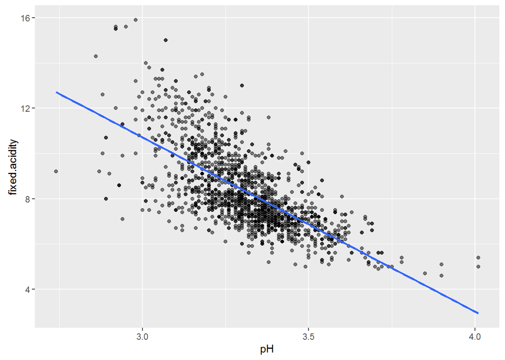

```
## [1] -0.6829782
```

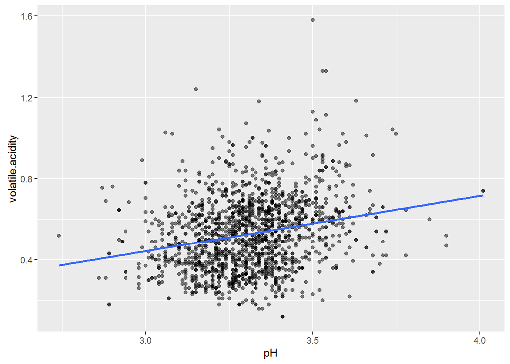

[output not shown]

Fixed acidity and volatile acidity are correlated with pH.

# Bivariate Analysis

### Talk about some of the relationships you observed in this part of the investigation. How did the feature(s) of interest vary with other features in the dataset?

Many of the scatterplots above confirmed what was suspected from the correlation visualisation at the start of the section. We saw for example that alcohol and quality correlate strongly together and that there is a negative correlation between volatile acidity and quality. We saw some relationships that weren’t expected. For example, the distribution for free and total sulfur dioxide were similar for bad wines (rated 3) and good wines (rated 8).

### Did you observe any interesting relationships between the other features (not the main feature(s) of interest)?

We saw interesting relationships between density, fixed acidity, alcohol and residual sugar. We also saw that the correlation between chlorides and sulphates might be misleading and that pH and acidity were correlated, as expected.

# Multivariate Plots Section

Begin by grouping all wines into 3 categories:

- bad (rated 3 - 4)
- average (rated 5 - 6) and
- good (rated 7 - 8)

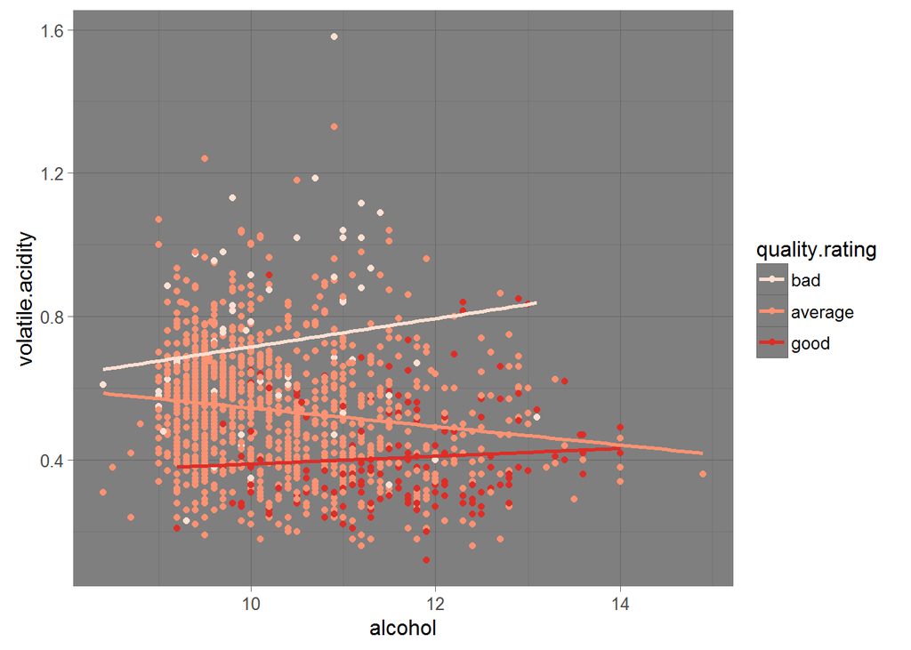

In the plot above, the regression lines nicely show the difference between the different quality wines. The good wines tend to have lower volatile acidity at all alcohol levels.

Let’s do the same for sulphates.

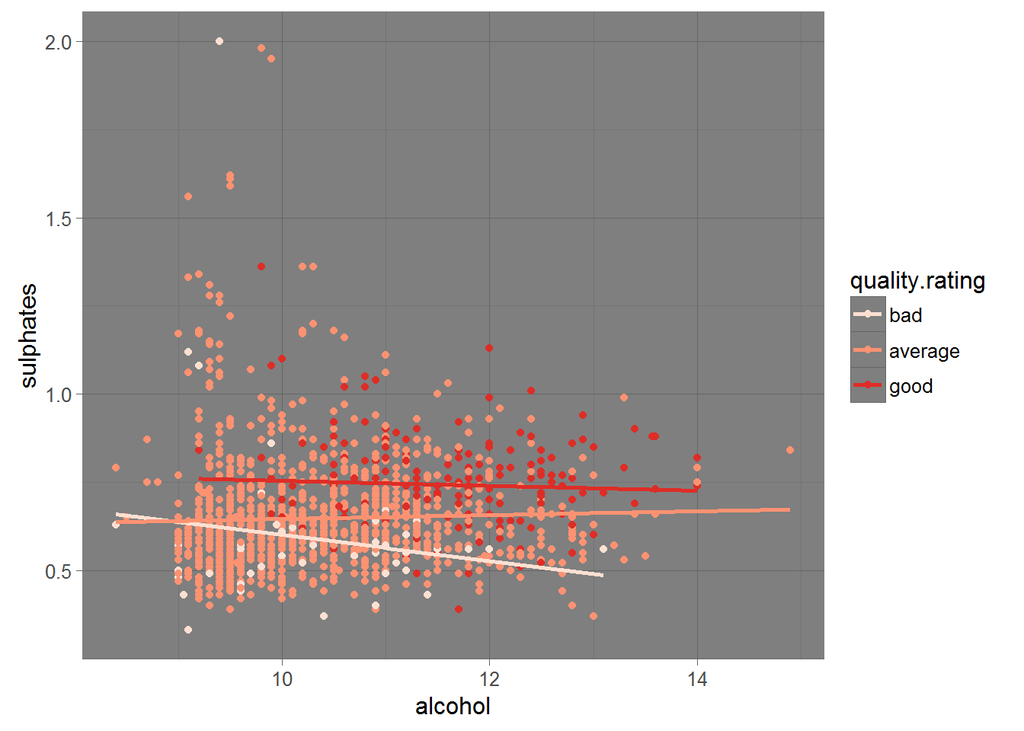

We see that for a given alcohol percentage, the amount of sulphates is higher.

Let’s plot fixed acidity and alcohol vs density and colour the scatter points by the quality rating.

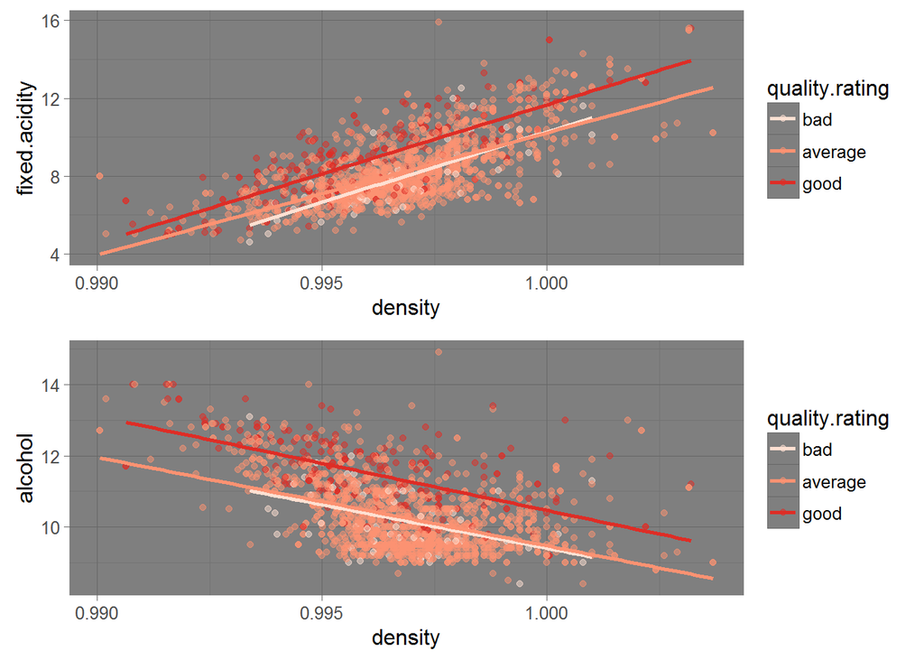

Let’s see what the chlorides vs sulphates scatterplot looks like when we consider the quality of the wine.

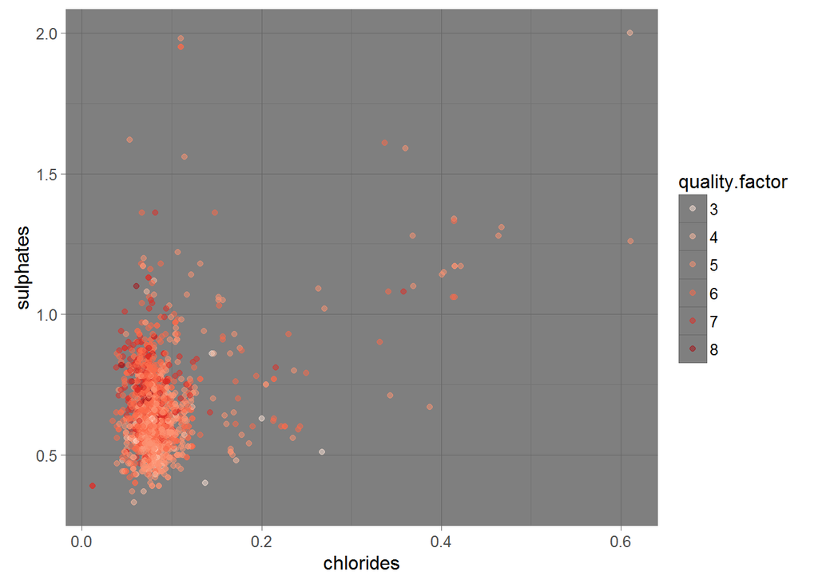

Let’s facet by quality rating and zoom in on the bulk of the data.

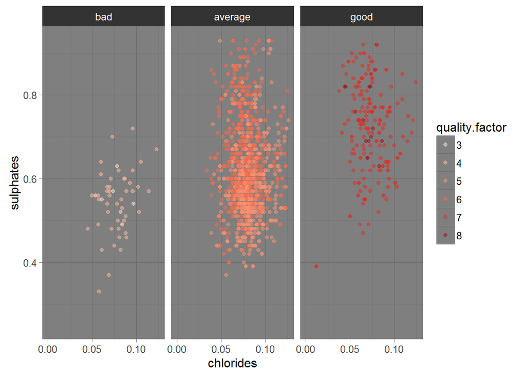

Wines of all quality tend to have chloride values between 0.05 and 0.125 (although wines rated 8 tend to be between 0.05 and 0.0875). We see that the sulphates values shift up the better the wine.

# Multivariate Analysis

### Talk about some of the relationships you observed in this part of the investigation. Were there features that strengthened each other in terms of looking at your feature(s) of interest?

The plots of volatile acidity vs alcohol and sulphates vs alcohol, both coloured by quality rating, didn’t reveal much more than what the bivariate analysis showed. It only reinforced that good wines tend to have higher alcohol content, lower volatile acidity and higher sulphates. It was interesting plotting fixed acidity vs density and and alcohol vs density and seeing the datapoints group into bad, average and good wines. Interestingly, the trendlines for bad and average wines were almost coincident, indicating that other factors were responsible for their differentiation.

# Final Plots and Summary

### Plot One

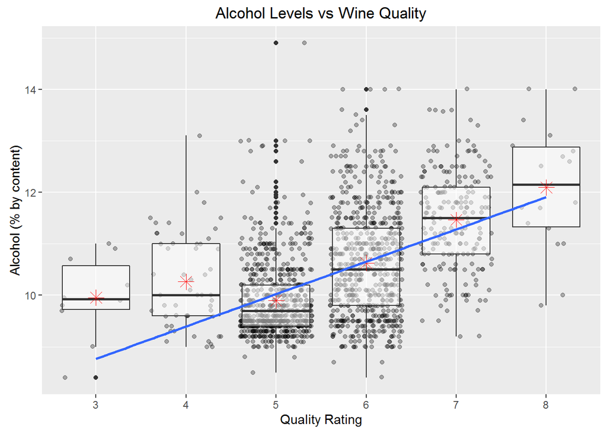

```
## [1] 0.4761663
```

### Description One

My objective was to understand which chemical properties influence the quality of a given red wine. It is for this reason that I chose to display a scatterplot of alcohol content vs wine quality, as the alcohol level is the property that correlates highest with quality, with r = 0.47. We can see that very bad wines (rated 3) have a mean alcohol content of approximately 10% whereas very good wines (rated 8) have an alcohol content of approximately 12%.

### Plot Two

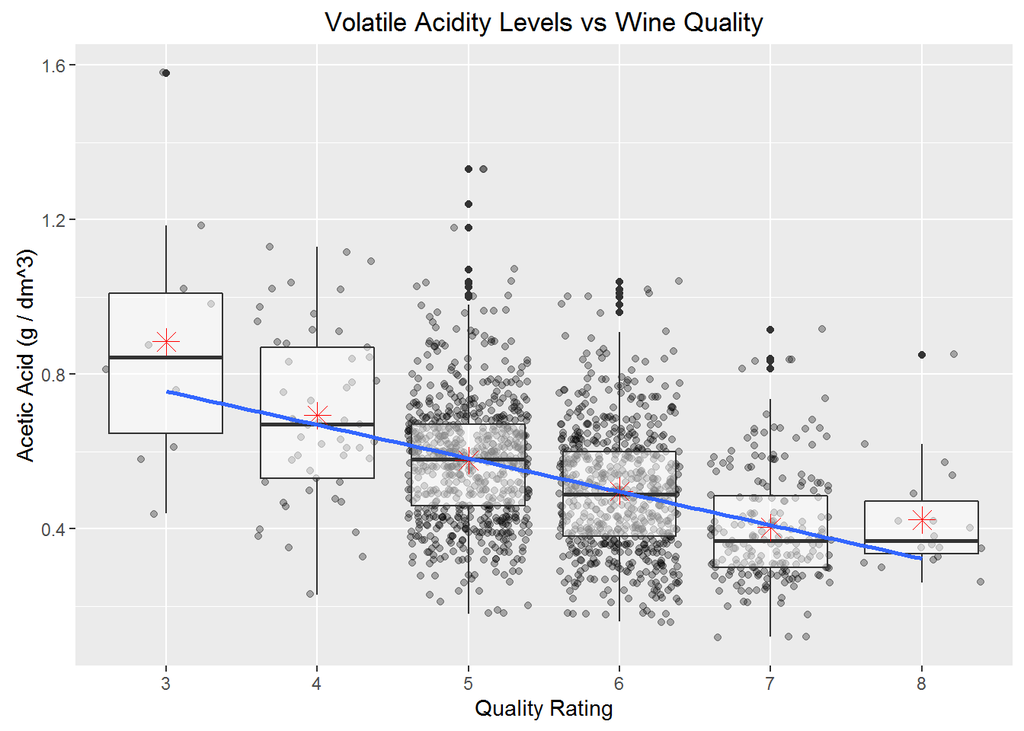

```
## [1] -0.3905578
```

### Description Two

I have also included a similar plot for volatile acidity vs wine quality. I did this because I believe that this plot, along with plot 1, offers insight into what makes a good wine. It shows that the better the wine the lower its volatile acidity levels. It’s a moderately strong correlation with r - -0.39.

### Plot Three

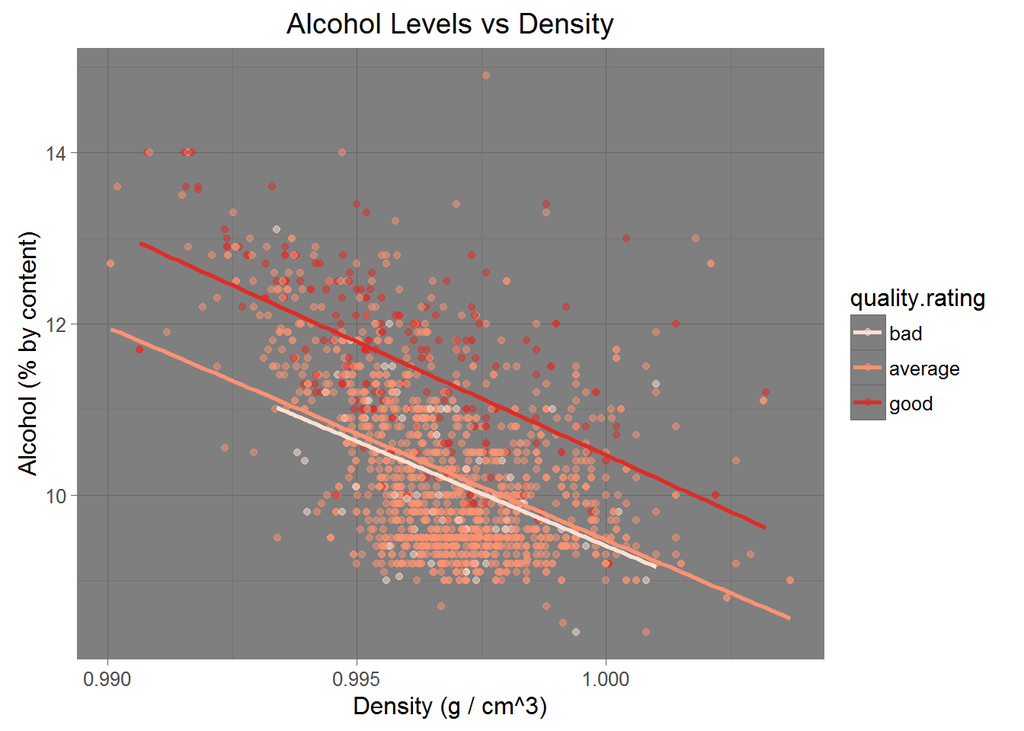

### Description Three

My final plot illustrates an interesting relationship between other features that are not the main feature of interest of my investigation. It shows the relationship between density and alcohol content. For a given density, a good wine has higher alcohol content than a bad or average wine.

# Reflection

The red wine data set contains information on 1599 Portugese Red Wines. To understand what chemical properites affect their quality, I started by understanding the individual variables in the data set, and seeing which ones correlated most highly with the quality rating. Based on these findings, I explored the data further, concentrating on the effect of alcohol, volatile acidity, sulphates content and citric acid.

My findings showed that most good red wines have a high alcohol, sulphate and citric acid levels and low volatile acidity. I consider this to be a success. I struggled to get a killer plot that would really help me understand what chemical properties made a good wine. Perhaps that is the learning - that there are many ways to skin a cat and there’s no one way to make a good wine.

Further work could be carried out to build a linear model to predict the quality of red wine. It would be interesting to incorporate variables that correlated less strongly with quality to refine the model.

It would also be interesting to see the extent to which the conclusions I drew above apply to wines from other areas of the world. This analysis was performed on Portuguese “Vinho Verde” Red Wine. Would it also apply to a wine from California or Peru?